# NavHealth Analysis

Getting intial data from the CMS website

```r
#data <- GET('https://data.cms.gov/resource/sdqm-3ic8.csv?$$app_token=T5ZPTWPOzfDH8oZK2D5dbsss5')
#data <- content(data)
dat <- read.csv('data.csv', stringsAsFactors=F)
setDT(dat)

data(zipcode)
setDT(zipcode)
zipcode <- zipcode[state=='KY']

setnames(dat, "Zip.Code.of.the.Provider", 'zipcode')
setnames(dat, 'City.of.the.Provider', 'city')
gsub('.{3}$', '', dat$zipcode)
dat$zipcode <- sub("^(\\d{5}).*$", "\\1", dat$zipcode)
dat <- merge(zipcode,
             dat,
             by.x='zip',
             by.y='zipcode')

setnames(dat, 'Last.Name.Organization.Name.of.the.Provider','Organization')
```

Get the coordinates for Bowling Green, KY with `ggmap` package function:

```r
BG <- geocode('Bowling Green, KY')
BG$city <- 'Bowling Green'
mapData <- setDT(map_data('county'))
mapData <- mapData[region=='kentucky']
```

Map the cardiologists by zipcode in the entire state

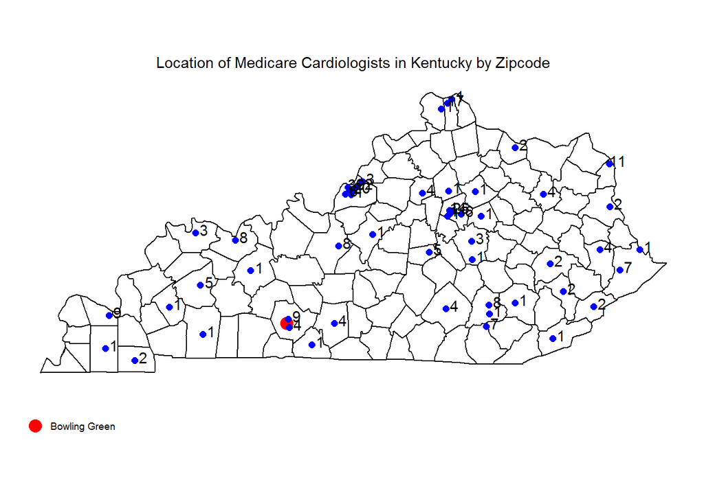

```r
ggplot() +
  geom_polygon(data=mapData, aes(x=long, y=lat, group=group), fill="white", color='black') +
  geom_point(data=BG, aes(x=lon, y=lat, col=city), size=4) +

  geom_point(data=dat[Provider.Type.of.the.Provider=='Cardiology'],
             aes(x=longitude,y=latitude), col='blue',  size=2) +

  geom_text(data=dat[Provider.Type.of.the.Provider=='Cardiology', .N, by=.(zip, latitude, longitude)],
            aes(x=longitude, y=latitude, label=N), nudge_x=.1, nudge_y=.03) +

  coord_map() +
  scale_color_manual(name=NULL, values='red') +
  ggtitle('Location of Medicare Cardiologists in Kentucky by Zipcode') +
  theme_map() +
  theme(legend.position='bottom') +# theme(legend.title=element())
  theme(plot.title = element_text(hjust = 0.5))
```

Bowling Green is the red dot; as such, it looks like there are cardiology providers in four zip codes in a reasonable proximity to Bowling Green. Referring to an online map and the dataset, the eastern zip code is for Glasgow, KY and the southeastern zip code is for Scottsville, Kentucky. Both are within 45 miles of Bowling Green.

For these three municipalities, Bowling Green has 13 cardiology providers, Glasgow has four, and Scottsville has one.

Combining these into one data.table for analysis:

```r
dat2 <- dat[city.x %in% c('Glasgow', 'Scottsville', 'Bowling Green') & Provider.Type.of.the.Provider=='Cardiology']
```

Report with info: https://www.cms.gov/research-statistics-data-and-systems/statistics-trends-and-reports/medicare-provider-charge-data/downloads/medicare-physician-and-other-supplier-puf-methodology.pdf

What variables might be interesting to look at here?

- National.Provider.Identifier
- Last.Name.Organization.Name.of.the.Provider
- Number.of.Services
- Number.of.Medicare.Beneficiaries"
- Total.Submitted.Charge.Amount
- Total.Medicare.Allowed.Amount
- Total.Medicare.Payment.Amount
- Total.Medicare.Standardized.Payment.Amount
- Percent…..of.Beneficiaries.Identified.With.Heart.Failure
- Number.of.Beneficiaries.With.Medicare.Only.Entitlement
- Number.of.Beneficiaries.With.Medicare…Medicaid.Entitlement
- Average.HCC.Risk.Score.of.Beneficiaries

There are three different groupings of payment/charge amounts: Total, Total.Drug, and Total.Medical. I chose to use only the first grouping because this had the most complete data for our subset (vs Total.Medical w/ some missing values) and better represented utilization costs than did Total.Drug, by my assumption.

Within those groupings there are four variables: Submitted.Charge.Amount, Medicare.Allowed.Amount, Medicare.Payment.Amount, and Medicare.Standardized.Payment.Amount.

The description for Total.Submitted.Charge.Amount in the documentation is “The total charges that the provider submitted for all services”

The description for Total.Medicare.Allowed.Amount is “The Medicare allowed amount for all provider services. This figure is the sum of the amount Medicare pays, the deductible and coinsurance amounts that the beneficiary is responsible for paying, and any amounts that a third party is responsible for paying.”

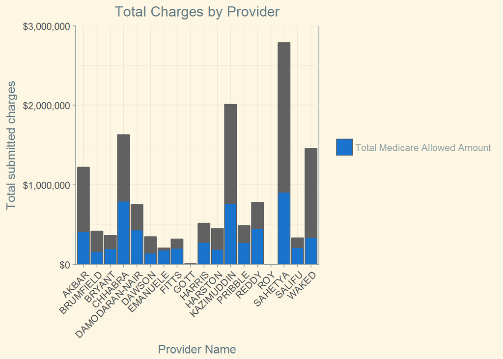

```r
ggplot(data=dat2) +
  geom_bar(aes(x=Organization,
               y=Total.Submitted.Charge.Amount),
           stat='identity', col='grey38', fill='grey38') +
  geom_bar(aes(x=Organization,
               y=Total.Medicare.Allowed.Amount, fill=state),
           stat='identity', col='grey38') +
  scale_fill_manual(name=NULL, labels=c('Total Medicare Allowed Amount'), values=c('dodgerblue3')) +
  xlab('Provider Name') + ylab('Total submitted charges') +
  ggtitle('Total Charges by Provider') +
  scale_y_continuous(labels=scales::dollar,expand = c(0, 0), limits = c(0, 3000000)) +
  theme_solarized(light=T) +
  theme(axis.text.x=element_text(angle=45, hjust=1)) +
  theme(plot.title = element_text(hjust = 0.5))
```

This plot shows that it is not uncommon for a provider to submit charges for services two or more times higher than the amount allowed by Medicare. It was not clear to me in my research whether that outstanding amount is paid, and if so, by whom, because the Medicare allowed amount value is stated to represent Medicare’s payment, the deductible and coinsurance payments and any third party payments. The bars are not stacked but rather overlaid.

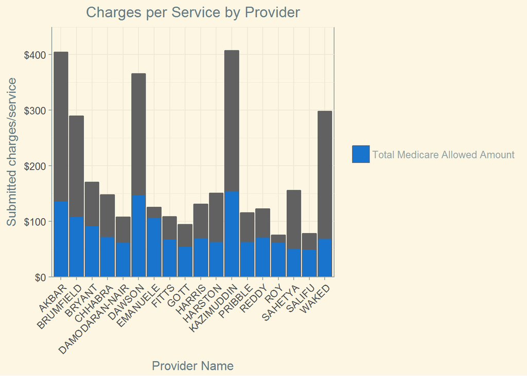

```r
ggplot(data=dat2) +
  geom_bar(aes(x=Organization,
               y=Total.Submitted.Charge.Amount/Number.of.Services),
           stat='identity',col='grey38', fill='grey38') +
  geom_bar(aes(x=Organization,
               y=Total.Medicare.Allowed.Amount/Number.of.Services, fill=state),
           stat='identity', color='grey38') +
  scale_fill_manual(name=NULL, labels=c('Total Medicare Allowed Amount'), values=c('dodgerblue3')) +
  xlab('Provider Name') + ylab('Submitted charges/service') +
  ggtitle('Charges per Service by Provider') +
  scale_y_continuous(labels=scales::dollar, expand = c(0, 0), limits = c(0, 450)) +
  theme_solarized(light=T) +
  theme(axis.text.x=element_text(angle=45, hjust=1)) +
  theme(plot.title = element_text(hjust = 0.5))
```

This plot shows the submitted charges and Medicare allowed amount per service using the ‘Number of Services’ variable. We can see that some providers charge significantly more per service than others on average, but that does not account for the type of services they are performing, an important factor. Note there are two variables, ‘Number of Services’ and ‘Number of Medical Services’; I chose the former because there was incomplete data for the latter.

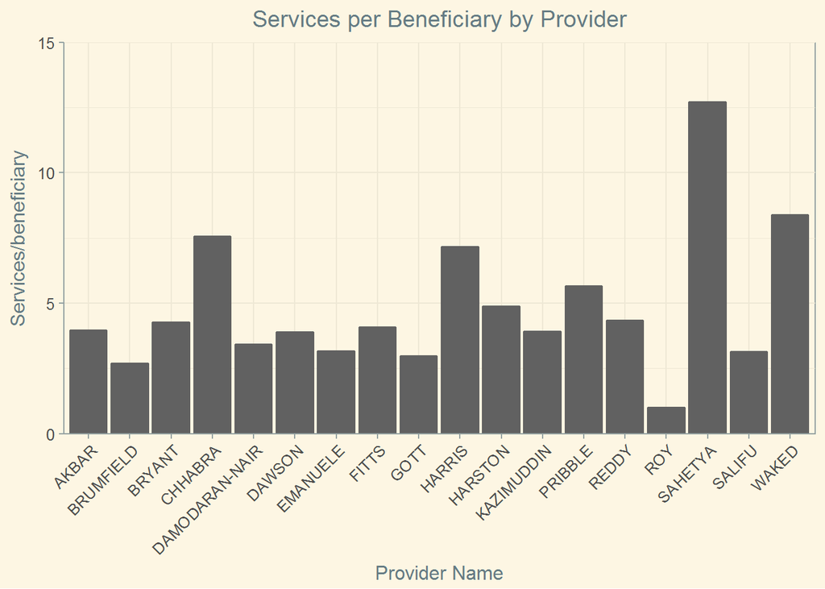

```r
ggplot(data=dat2) +
  geom_bar(aes(x=Organization,
               y=Number.of.Services/Number.of.Medicare.Beneficiaries),
           stat='identity',col='grey38', fill='grey38') +
  xlab('Provider Name') + ylab('Services/beneficiary') +
  ggtitle('Services per Beneficiary by Provider') +
  scale_y_continuous(expand = c(0, 0), limits = c(0, 15)) +
  theme_solarized(light=T) +
  theme(axis.text.x=element_text(angle=45, hjust=1)) +
  theme(plot.title = element_text(hjust = 0.5))
```

Exploratory plots:

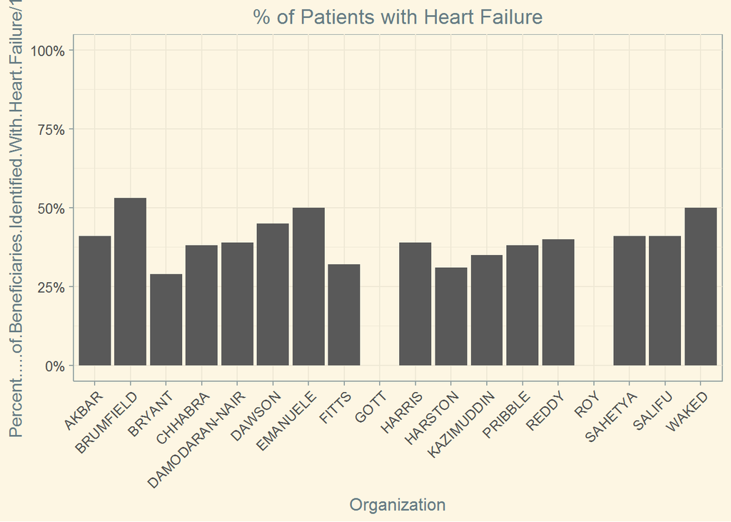

```r
ggplot(data=dat2, aes(x=Organization,
                      y=Percent.....of.Beneficiaries.Identified.With.Heart.Failure/100)) +
  geom_bar(stat='identity') +
  scale_y_continuous(limits=c(0,1),labels = scales::percent) +
  ggtitle('% of Patients with Heart Failure') +
  theme_solarized(light=T) +
  theme(axis.text.x=element_text(angle=45, hjust=1)) +
  theme(plot.title=element_text(hjust=.5))
```

Scores greater than 1.08 are expected to have higher than average spending:

Do more visits per beneficiary mean better patient outcomes?

```r
g <- ggplot(data=dat2, aes(y=Number.of.Services/Number.of.Medicare.Beneficiaries,
                      x=Average.HCC.Risk.Score.of.Beneficiaries)) +
  geom_point(aes(group=Organization)) +
  geom_smooth(method='lm', formula=y~x, se=FALSE) +
  ylab('Services per beneficiary')

ggplotly(g, tooltip=c('Organization'))
```

[interactive chart not shown]

Does more money per patient charged mean better patient outcomes?

```r
g <- ggplot(data=dat2, aes(y=Total.Submitted.Charge.Amount/Number.of.Medicare.Beneficiaries,
                      x=Average.HCC.Risk.Score.of.Beneficiaries)) +
  geom_point(aes(group=Organization)) +
  geom_smooth(method='lm', formula=y~x, se=FALSE) +
  ylab('Dollars per beneficiaries')

ggplotly(g, tooltip=c('Organization'))
```

[interactive chart not shown]

Or more money per service

```r
g <- ggplot(data=dat2, aes(y=Total.Submitted.Charge.Amount/Number.of.Services,
                      x=Average.HCC.Risk.Score.of.Beneficiaries)) +
  geom_point(aes(group=Organization)) +
  geom_smooth(method='lm', formula=y~x, se=FALSE) +
  ylab('Dollars per service')

ggplotly(g, tooltip=c('Organization'))
```

[interactive chart not shown]

```r
dat2[, Dollars_per_service := Total.Submitted.Charge.Amount/Number.of.Services]
dat2[, Services_per_patient := Number.of.Services/Number.of.Medicare.Beneficiaries]
dat2[, Dollar_per_patient := Total.Submitted.Charge.Amount/Number.of.Medicare.Beneficiaries]
```

```r
DT::datatable(dat2[,c(6,7,21,22,23,24,74,75,77,76),with=FALSE],
              colnames=c('NPI','Org. Name','Num. of Services','Num. of Medicare Beneficiaries','Total Submitted Charge','Total Medicare Allowed Amount','Avg. Beneficiary HCC Risk Score','Dollars per Service','Dollars per Beneficiary','Services per Beneficiary')) %>%
  formatCurrency(c(5,6,8,9), '$', digits=0) %>%
  formatCurrency(c(3,4,8), '') %>%
  formatCurrency(c(7), '', digits=4) %>%
  formatRound(c(3,4,10), digits=0)
```

|  | NPI | Org. Name | Num. of Services | Num. of Medicare Beneficiaries | Total Submitted Charge | Total Medicare Allowed Amount | Avg. Beneficiary HCC Risk Score | Dollars per Service | Dollars per Beneficiary | Services per Beneficiary |
| --- | --- | --- | --- | --- | --- | --- | --- | --- | --- | --- |
| 1 | 1649258088 | SAHETYA | 17934 | 1412 | 2785989 | 908465.65 | 1.581 | 155.346771495483 | 1973.08002832861 | 12.7011331444759 |
| 2 | 1992952501 | DAWSON | 946 | 243 | 345738.75 | 140250.72 | 1.5855 | 365.474365750529 | 1422.79320987654 | 3.89300411522634 |
| 3 | 1821124504 | BRUMFIELD | 1446 | 535 | 418829.54 | 158297.2 | 1.8421 | 289.646984785615 | 782.858953271028 | 2.70280373831776 |
| 4 | 1487826814 | ROY | 16 | 16 | 1200 | 993.28 | 1.4761 | 75 | 75 | 1 |
| 5 | 1932304813 | WAKED | 4883 | 582 | 1456383 | 336264.45 | 1.6894 | 298.255785377842 | 2502.37628865979 | 8.39003436426117 |
| 6 | 1053310409 | KAZIMUDDIN | 4939 | 1258 | 2012402.39 | 760741.08 | 1.5041 | 407.451384895728 | 1599.68393481717 | 3.92607313195548 |
| 7 | 1730185166 | PRIBBLE | 4253 | 751 | 490416 | 270501.83 | 1.5675 | 115.310604279332 | 653.017310252996 | 5.66311584553928 |
| 8 | 1083655047 | EMANUELE | 1647 | 518 | 206509.54 | 175608.13 | 1.7906 | 125.385270188221 | 398.667065637066 | 3.17953667953668 |
| 9 | 1205887858 | CHHABRA | 10996 | 1455 | 1628911 | 793593.16 | 1.5969 | 148.136686067661 | 1119.5264604811 | 7.5573883161512 |
| 10 | 1437188984 | FITTS | 2934 | 717 | 317963 | 200452.19 | 1.3675 | 108.37184730743 | 443.463040446304 | 4.09205020920502 |

[output cut: 8 more lines]